# Introduction to

2025-01-02

# esqlabsR ?

## `{esqlabsR}` What ?

- R package
- for PBK and QSP/T Modeling
- Based on [Open Systems Pharmacology Software](https://www.open-systems-pharmacology.org/)

`{esqlabsR}` ?

## `{esqlabsR}` Why ?

- Simple functions to design, run, and save simulations,
- Store a whole modeling project as plain text files,
- Generate standardized plots automatically.

**➡️ Streamlined simulation workflow 🚀**

`{esqlabsR}` ?

## `{esqlabsR}` Where ?

- Code repository: github.com/esqLABS/esqlabsR
- Documentation: [esqlabs.github.io/esqlabsR/](https://esqlabs.github.io/esqlabsR)
- [Get started tutorial](https://esqlabs.github.io/esqlabsR/articles/esqlabsR.html)

`{esqlabsR}` ?

## `{esqlabsR}` How ?

```r
install.packages("pak")

pak::pak("esqLABS/esqlabsR*release")
```

**📦 Installation**

## `{esqlabsR}` How ?

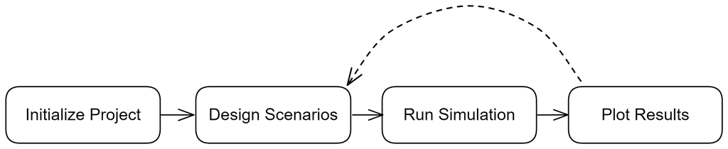

**esqlabsR workflow**

`{esqlabsR}` ?

# Get started

# I. The project

## What is a project ?

A **Project** holds everything a simulation needs: models, scenarios, individuals, populations, parameters, output paths, observed data, and plots.

On disk, a project is a directory. In R, it is one object you load once and pass to every workflow function.

```r
library(esqlabsR)
project <- loadProject("path/to/Project.json")
```

I The project

## Start a new project

`initProject()` scaffolds the directory structure for you.

```r
# An empty project to fill in
initProject("my_project", type = "minimal")

# A ready-to-run worked example
initProject("my_example", type = "example")
```

The bundled worked example is one call away:

```r
project <- loadProject(exampleProjectPath())
```

I The project

## A project is a directory

A `Project.json` container plus a `definitions/` tree, one JSON file per entity.

```bash
my_project
├── Project.json
├── definitions
│   ├── scenarios
│   │   └── aciclovir_iv.json
│   ├── individuals
│   │   └── adult_male.json
│   ├── populations
│   │   └── european_adults.json
│   ├── parameter-sets
│   │   ├── global.json
│   │   └── aciclovir.json
│   ├── applications
│   │   └── aciclovir_iv_250mg.json
│   ├── output-paths
│   │   └── aciclovir_pvb.json
│   └── plots
│       └── plots.json
├── Models
│   └── Simulations
│       └── Aciclovir.pkml
├── Data
└── Results
```

I The project

## A project is a directory

`Project.json` is the container; the `definitions/` tree is the source of truth.

```bash
my_project
├── Project.json
├── definitions
│   ├── scenarios
│   │   └── aciclovir_iv.json
│   ├── individuals
│   │   └── adult_male.json
│   ├── populations
│   │   └── european_adults.json
│   ├── parameter-sets
│   │   ├── global.json
│   │   └── aciclovir.json
│   ├── applications
│   │   └── aciclovir_iv_250mg.json
│   ├── output-paths
│   │   └── aciclovir_pvb.json
│   └── plots
│       └── plots.json
├── Models
│   └── Simulations
│       └── Aciclovir.pkml
├── Data
└── Results
```

I The project

## One object, every section

`loadProject()` reads the whole tree into a single `Project` object.

```r
project
```

```
<Project> (schema 2.0)
  name:            Example
  description:     Aciclovir IV PK example project
  jsonPath:        /Library/Frameworks/R.framework/Versions/4.6/Resources/library/esqlabsR/extdata/projects/Example/Project.json
  esqlabsRVersion: 6.0.0
  files:
    modelFolder:         /Library/Frameworks/R.framework/Versions/4.6/Resources/library/esqlabsR/extdata/projects/Example/Models/Simulations
    configurationsFolder:/Library/Frameworks/R.framework/Versions/4.6/Resources/library/esqlabsR/extdata/projects/Example/Configurations
    dataFolder:          /Library/Frameworks/R.framework/Versions/4.6/Resources/library/esqlabsR/extdata/projects/Example/Data
    outputFolder:        /Library/Frameworks/R.framework/Versions/4.6/Resources/library/esqlabsR/extdata/projects/Example/Results
  scenarios:       3
  individuals:     1
  populations:     1
  parameterSets:   4 set(s)
  applications:    1
  outputPaths:     2
  observedData:    1 source(s)
  dataCombined:    1
  plots:           1
  plotGrids:       1
  parameterIdentification: 1 task(s)
```

I The project

## Share a project as one file

A **snapshot** packs a project into a single portable `.esqlabsR` file.

```r
# Freeze the project into one shareable file
saveSnapshot(project, "aciclovir_study")  # writes aciclovir_study.esqlabsR

# Re-materialize it as a full project directory
loadSnapshot("aciclovir_study.esqlabsR", dir = "restored_project")
```

- Plain text, JSON-based (Git-friendly)
- One file to send a colleague
- Reproducible project setup

I The project

# II. Authoring scenarios

## Scenarios

Simulations are defined by **Scenarios**.

A scenario pins down a model, an individual or population, an application, the parameter sets to apply, a time grid, and the output paths to record.

```r
names(project$scenarios)
```

```
[1] "aciclovir_iv"             "aciclovir_iv_population"
[3] "aciclovir_iv_steadystate"
```

II Authoring scenarios

## What a scenario links

```
flowchart TD
    Scenario["`**Scenario**
    aciclovir_iv`"]

    Model["`**Model**
    Aciclovir.pkml`"]

    ParamSets["`**Parameter Sets**
    global
    aciclovir`"]

    Application["`**Application**
    aciclovir_iv_250mg`"]

    Individual["`**Individual**
    adult_male`"]

    OutputPaths["`**Output Paths**
    aciclovir_pvb`"]

    Scenario -->|modelFile| Model
    Scenario -->|parameterSets| ParamSets
    Scenario -->|application| Application
    Scenario -->|individual| Individual
    Scenario -->|outputPaths| OutputPaths

    style Scenario fill:#e1f5e1,stroke:#4caf50,stroke-width:3px
    style Model fill:#fff9c4,stroke:#fbc02d,stroke-width:2px
    style ParamSets fill:#e1f5e1,stroke:#4caf50,stroke-width:2px
    style Application fill:#e1f5e1,stroke:#4caf50,stroke-width:2px
    style Individual fill:#e1f5e1,stroke:#4caf50,stroke-width:2px
    style OutputPaths fill:#e1f5e1,stroke:#4caf50,stroke-width:2px
```

II Authoring scenarios

## Authoring in R

The `add*` / `set*` / `remove*` family edits a project by id.

```r
# Output path: a short id bound to an OSPS-notation path
addOutputPath(
  project,
  id = "aciclovir_pvb",
  path = "Organism|PeripheralVenousBlood|Aciclovir|Plasma (Peripheral Venous Blood)"
)

# Scenario referencing definitions by their ids
addScenario(
  project,
  id = "aciclovir_iv",
  modelFile = "Aciclovir.pkml",
  individual = "adult_male",
  application = "aciclovir_iv_250mg",
  parameterSets = c("global", "aciclovir"),
  outputPaths = "aciclovir_pvb"
)
```

II Authoring scenarios

## Authoring is write-through

Every edit lands in its entity file immediately. There is no separate save step.

```r
# Build a parameter set entry by entry
addParameterSet(project, id = "aciclovir")
addParameterEntry(
  project,
  id = "aciclovir",
  containerPath = "Aciclovir",
  parameterName = "Lipophilicity",
  value = -0.09,
  units = "Log Units"
)

# Add an individual
addIndividual(project, id = "adult_male", species = "Human", gender = "MALE")
```

Ids are canonicalized: lowercased and made filename-safe.

II Authoring scenarios

# III. Run simulations

## Run scenarios

`runScenarios()` takes the project and the scenario ids to run.

```r
results <- runScenarios(project, scenarios = "aciclovir_iv")
```

It returns a **Scenario Result** list, keyed by scenario name.

```r
names(results)
```

```
[1] "aciclovir_iv"
```

```r
names(results$aciclovir_iv)
```

```
[1] "simulation"   "results"      "outputValues" "population"
```

III Run simulations

## Inside a Scenario Result

| IndividualId | Time | Organism\|PeripheralVenousBlood\|Aciclovir\|Plasma (Peripheral Venous Blood) |
| --- | --- | --- |
| 0 | 0 | 0 |
| 0 | 1 | 2.71324563026428 |
| 0 | 2 | 7.83073997497559 |
| 0 | 3 | 13.1094131469727 |
| 0 | 4 | 18.2589435577393 |
| 0 | 5 | 23.2433490753174 |

Each result bundles the simulation, the raw results, the extracted output values, and the population (when there is one).

III Run simulations

# IV. Plot results

## DataCombined and plots

Plots are declared in the project. `createPlots()` reads them and the simulated scenarios, and returns **Plot Grids**.

```r
grids <- createPlots(project, scenarioResults = results)

grids[["individual_diagnostics"]]
```

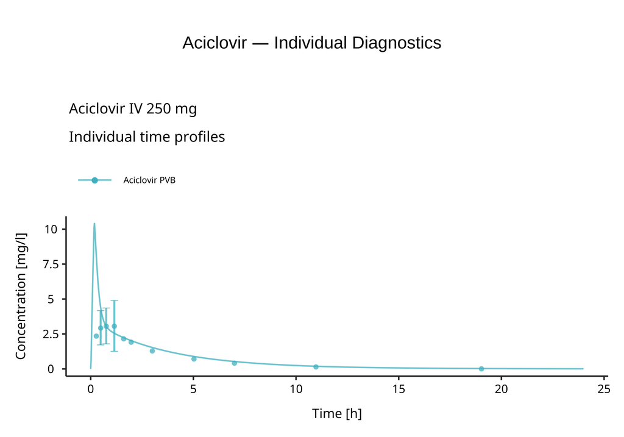

IV Plot results

## Combine data yourself

Need finer control ? Build the `DataCombined` directly with `createDataCombined()`, then plot with the `{ospsuite}` workflow.

```r
dc <- createDataCombined(
  project,
  dataCombinedNames = "aciclovir_individual",
  scenarioResults = results
)

ospsuite::plotIndividualTimeProfile(dc$aciclovir_individual)
```

IV Plot results

# V. And more

## Validation

`validateProject()` checks every section and the cross-references between them, returning one result per section.

```r
results <- validateProject(project)

if (isAnyCriticalErrors(results)) {
  print(validationSummary(results))
}
```

V And more

## Parameter identification & sensitivity

Fit parameters to observed data, declared as tasks in the project:

```r
piResults <- runPI(project, tasks = "aciclovirsimple")
```

Quantify how outputs respond to parameter changes:

```r
sens <- sensitivityCalculation(
  simulation = results$aciclovir_iv$simulation,
  outputPaths = project$outputPaths[["aciclovir_pvb"]],
  parameterPaths = "Aciclovir|Lipophilicity"
)
```

V And more

## Excel bridge

Prefer spreadsheets ? Move a project to and from Excel without losing the working tree.

```r
# Excel -> working tree project
project <- importProjectFromExcel("Project.xlsx")

# Project -> Excel mirror
exportProjectToExcel(project, outputDir = "excel_export")
```

The project tree stays authoritative; the round trip is a fixed point.

V And more

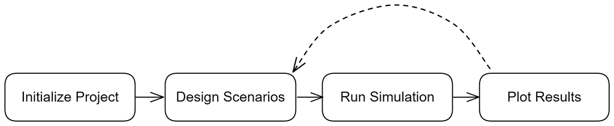

## Help us improve esqlabsR

- Install & try,
- Add a ⭐ to the github repository,
- Leave comments/requests at: github.com/esqLABS/esqlabsR/issues

**Thank you**